# Project stm model: Disease

A. Pedraza

2024-12-04

### Data Processing

- Download data from csv file.
- Summary of data frame:
  - 3 columns: Abstract, Journal title, Year of publication
  - 1084 observations.
  - **Year** parameter spans from 2010-2024

```r
# Download csv file
df_disease<- read.csv("final_df_disease.csv")
print(summary(df_disease))
```

```
##    Abstract           Journal               Year
##  Length:1084        Length:1084        Min.   :2010
##  Class :character   Class :character   1st Qu.:2015
##  Mode  :character   Mode  :character   Median :2018
##                                        Mean   :2018
##                                        3rd Qu.:2021
##                                        Max.   :2024
```

**Data Frame Example**

```r
kbl(head(df_disease)) %>%
  kable_styling(bootstrap_options = c("striped", "hover", "condensed"))
```

| Abstract | Journal | Year |
| --- | --- | --- |
| Recent data demonstrate alarming increases in mortality from cardiovascular disease and increase in risk factors that are pushing this disease to epidemic proportions in Asians living in the Bay Area … | Hawaii medical journal | 2010 |
| High resolution proton magnetic resonance spectroscopy (1H-NMR) of body fluids coupled with multivariate data analysis has led to a new science known as metabonomics. Metabonomics is a powerful tool f… | Journal of nephrology | 2010 |
| Fabry disease (FD) is an X-linked lysosomal storage disorder caused by mutations in the gene encoding the lysosomal enzyme a-galactosidase A (a-GalA). The resulting deficiency in a-GalA activity leads… | Journal of nephrology | 2010 |
| Klotho is a single-pass transmembrane protein that exerts its biological functions through multiple modes. Membrane-bound Klotho acts as coreceptor for the major phosphatonin fibroblast growth factor-… | Journal of nephrology | 2010 |
| Invasive mould disease is a growing threat for immunocompromised patients. The optimum time to use mould-active antifungal agents is much debated. Current approaches to antifungal prophylaxis, early t… | The Journal of antimicrobial chemotherapy | 2010 |
| Randomized controlled trials (RCTs) provide the most reliable estimates of the effects of treatments. However, not all treatments are compared in available RCTs, making comparison of treatments proble… | The Journal of antimicrobial chemotherapy | 2010 |

### Histogram of Years Represneted

- Year 2014 is missing. There was an issue with retrieving data from that year for this assignment.

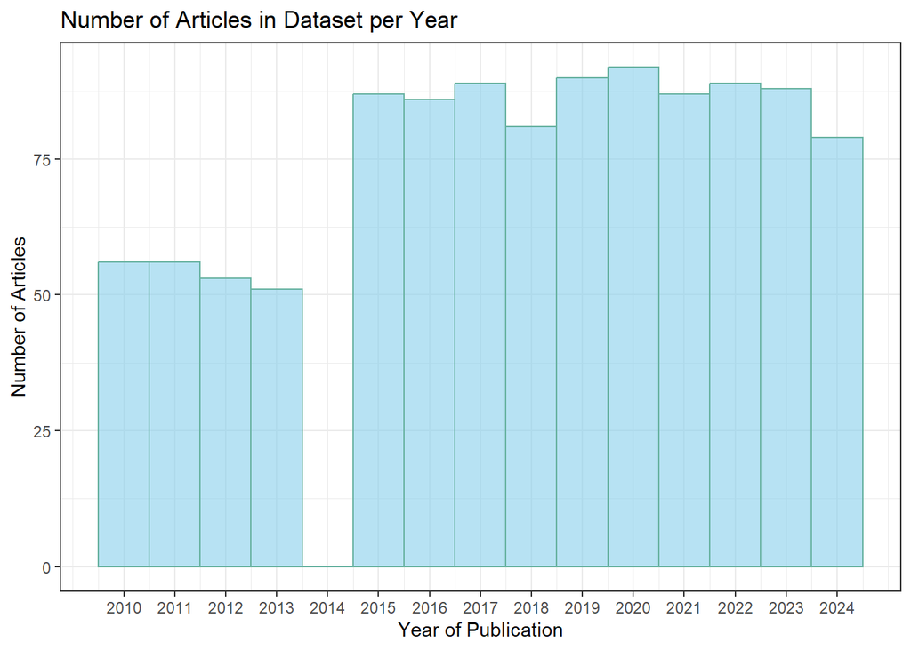

```r
df_disease %>%
  ggplot( aes(x=Year, fill=Year)) +
    geom_histogram(bins=15, fill='skyblue', color='#69b3a2', alpha=.6, width=.4) + scale_x_continuous(breaks=seq(2010,2024,1))+
    #scale_fill_manual(values=c("#69b3a2", "#404080")) +
    theme_bw() + ggtitle("Number of Articles in Dataset per Year") + xlab("Year of Publication") +
  ylab("Number of Articles")
```

### Processing Data for stm()

- documents = The journal abstracts from the dataset from 2010 - 2024
- metadata = The journal name and the year the article was published in the journal
- Using textProcessor() to process the abstracts, journal titles putting them in lowercase. I chose stem=FALSE since I wanted to make sure medical terms were kept intact.

```r
documents <- df_disease$Abstract
journal <- df_disease$Journal
year <- df_disease$Year

metadata <- data.frame(journal, year)

processed_disease <- textProcessor(documents = documents, metadata = metadata ,stem=FALSE)
```

```
## Building corpus...
## Converting to Lower Case...
## Removing punctuation...
## Removing stopwords...
## Removing numbers...
## Creating Output...
```

```r
out_disease<- prepDocuments(processed_disease$documents, processed_disease$vocab, processed_disease$meta, lower.thresh = 25)
```

```
## Removing 16249 of 17028 terms (47011 of 98904 tokens) due to frequency
## Your corpus now has 1084 documents, 779 terms and 51893 tokens.
```

#### stm() with prevalence = ~ journal + year

- The documents to review are the abstracts.
- prevalence: my equation for prevalence includes both the year and journal data.
- After some previous runs, the maximum iterations needed were at most 100. Therefore, max.em.its = 100
- Used gamma.prior = ‘L1’ to speed up the iteration process

```r
stm_fit_disease<- stm(documents = out_disease$documents, vocab = out_disease$vocab, K =5, prevalence = ~ year + journal, max.em.its = 100, data = out_disease$meta, init.type = "Spectral", gamma.prior = 'L1',   seed = 237)
```

[output not shown]

[output cut: 356 more lines]

[output not shown]

### Results

**Summary Plot**

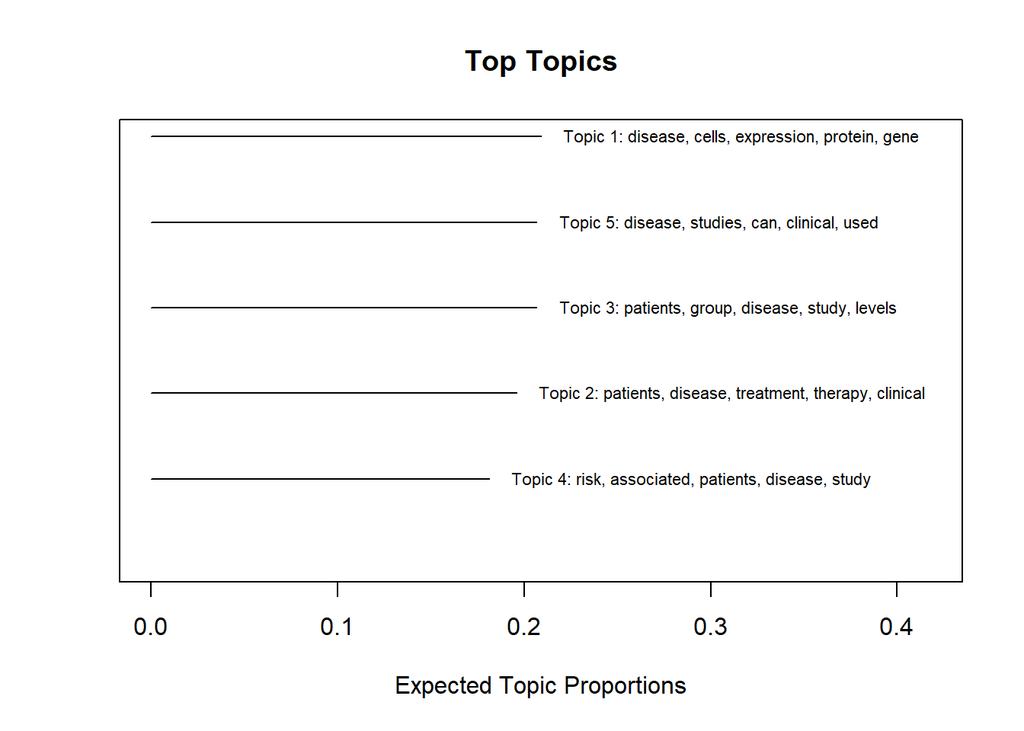

```r
plot(stm_fit_disease, type = "summary", n=5, text.cex = .7)
```

### Top Abstracts for Each of the Topics

- Extract the top 2 Abstracts for each Topic using findThoughts() function.

**Topic 1:**

**Label: Inflammatory Diseases Cells and Treatment**

```r
topic1_thoughts <- findThoughts(stm_fit_disease, text = documents, n=2, topics = 1)$docs[[1]]
print(paste0(topic1_thoughts[1]))
```

```
## [1] "c-Rel is a member of the nuclear factor ÎºB (NF-ÎºB) transcription factor family. Unlike other NF-ÎºB proteins that are expressed in a variety of cell types, high levels of c-Rel expression are found primarily in B and T cells, with many c-Rel target genes involved in lymphoid cell growth an…
```

```r
print(paste0(topic1_thoughts[2]))
```

```
## [1] "Parkinson's disease (PD) is characterized by the selective loss of nigrostriatal dopamine neurons associated with microglial activation. Inhibition of the inflammatory response elicited by activated microglia could be an effective strategy to alleviate the progression of PD. Here, we synthes…
```

**Topic 2: The Top 2 Abstracts**

**Label: Disease Pain and Treatment**

```r
topic2_thoughts <- findThoughts(stm_fit_disease, text = documents, n=2, topics = 2)$docs[[1]]
print(paste0(topic2_thoughts[1]))
```

```
## [1] "The purpose of this study was to evaluate the long term results of 19 painful dislocated hips in patients with spastic cerebral palsy (CP) who were treated with hip arthrodesis and internal fixation. The study included 19 patients with spastic CP with a mean age of 17 years and five months (…
```

```r
print(paste0(topic2_thoughts[2]))
```

```
## [1] "Kyrle's disease (KD) is a primary perforating dermatosis that affects more commonly 30-50Â year old females, and clinically characterized by pruritic hyperkeratotic and ulcerated nodules, papules and plaques, localized on extensor surface of upper and lower limbs, and on the trunk. To determ…
```

**Topic 3: The Top 2 Abstracts**

**Label: Autoimmune diseases and Relative Diseases**

- First abstract is on Parkinson’s Disease and the second abstract is on Behcet’s disease which is an autoimmune disorder that affects many parts of the body. Parkinson’s disease also affects many parts of the body but is mostly noticed in the person’s gait. Although Parkinson’s disease is not considered to be an autoimmune disease, as stated below, there is some reasearch to suggest that it could play a role.
- It is interesting that stm() has grouped these two abstracts together. After reading both of the abstracts, it is difficult to understand what they have in common. But after researching the two disease separately and finding that there is a possiblity that PD may have a linke to autoimmune diseases, it makes sense that the model has grouped them into a topic.
- Although there is no word “autoimmune” in either of the abstracts, one could understand that the latent topic here is autoimmune disease.
- From Google AI:

“While Parkinson’s disease is not typically considered a full-fledged autoimmune disease, growing research suggests that autoimmune mechanisms may play a role in its development.”

```r
topic3_thoughts <- findThoughts(stm_fit_disease, text = documents, n=2, topics = 3)$docs[[1]]
print(paste0(topic3_thoughts[1]))
```

```
## [1] "Gait initiation is a major motor problem for patients with Parkinson's disease (PD). To understand the gait initiation in patients with PD, fluctuation on the first three steps of initiation was examined Force distribution measurement platform was used to record gait initiation in 10 patient…
```

```r
print(paste0(topic3_thoughts[2]))
```

```
## [1] "Behcet's disease (BD) is a chronic, relapsing, systemic vasculitis of unknown etiology. To measure serum ghrelin levels in BD patients and healthy controls and to investigate its association with metabolic syndrome (MetS). Thirty BD patients and 30 healthy individuals were enrolled in the st…
```

**Topic 4: The Top 2 Abstracts**

- **Label: Cardiovascuar Disease Risk and Treatment**

```r
topic4_thoughts <- findThoughts(stm_fit_disease, text = documents, n=2, topics = 4)$docs[[1]]
print(paste0(topic4_thoughts[1]))
```

```
## [1] "Cardiovascular disease (CVD) is a major source of mortality and morbidity in dialysis patients. Population-level descriptions of CVD medication use are lacking in this population. Retrospective cohort study. Adult dialysis patients in the United States, alive on December 31, 2006, with Medic…
```

```r
print(paste0(topic4_thoughts[2]))
```

```
## [1] "The role of dietary calcium in cardiovascular disease prevention is unclear. We aimed to determine the association between calcium intake and incident cardiovascular disease and mortality. Data were extracted from the European Prospective Investigation of Cancer, Norfolk (EPIC-Norfolk). Mult…
```

**Topic 5: The Top 2 Abstracts**

- **Label: Infectious Disease: Prevention and Control**

```r
topic5_thoughts <- findThoughts(stm_fit_disease, text = documents, n=2, topics = 5)$docs[[1]]
print(paste0(topic5_thoughts[1]))
```

```
## [1] "For the response to a zoonotic disease outbreak to be effective, animal health authorities and disease specialists must be involved. Animal health measures are commonly directed at known diseases that threaten the health of animals and impact owners. The measures have long been applied to zo…
```

```r
print("------------------------------")
```

```
## [1] "------------------------------"
```

```r
print(paste0(topic5_thoughts[2]))
```

```
## [1] "Plague, a highly infective disease caused by Yersinia pestis (Proteobacteria: Enterobacteriales), ravaged Europe from 1347 over the course of more than 450â\200¯years. During the Italian Plague (1629-1631), the disease was rampaging in the entire Northern Italy down to Tuscany, but the city …
```

### Metadata Relationship with Topics**

```r
#out_disease$meta$year <- as.numeric(out_disease$meta$year)
prep <- estimateEffect(1:5 ~ year , stm_fit_disease, meta = out_disease$meta, uncertainty = "Global")
```

**Topics 1 and 2**

- Topic 1: Inflammatory Diseases Treatments and Cells
- Topic 2: Disease Pain and Treatment
- Topic 1, Inflammatory Diseases and Treatments and Cells, shows a decline over the same 14 years.
- Topic 2, Disease Pain and Treatment, seems to be level over the past 14 years in terms of publications.

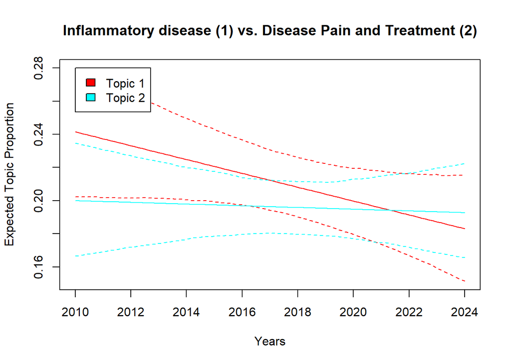

```r
plot(prep, covariate = "year", method = "continuous", topics = c(1,2), model = stm_fit_disease, xlab = "Years", main = "Inflammatory disease (1) vs. Disease Pain and Treatment (2)" )
```

**Topics 3 and 4**

- Topic 3: Autoimmune diseases and Relative Diseases, has remained steady in the number of publications.
- Topic 4: Cardiovascuar Disease Risk and Treatment, has shown an increase in the number of publications.

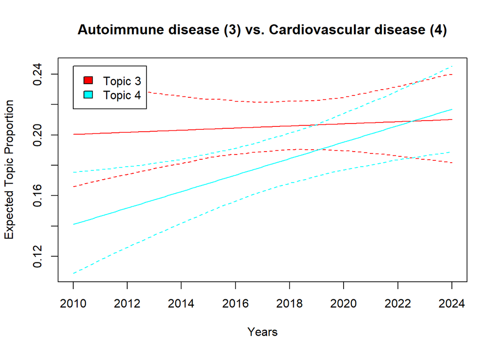

```r
plot(prep, covariate = "year", method = "continuous", topics = c(3,4), model = stm_fit_disease, xlab = "Years", main = "Autoimmune disease (3) vs. Cardiovascular disease (4)")
```

**Topics 4 and 5**

- Topic 4: Cardiovascuar Disease Risk and Treatment, has shown an increase in the number of publications.
- Topic 5: Infectious Disease: Prevention and Control has remained mostly the same.

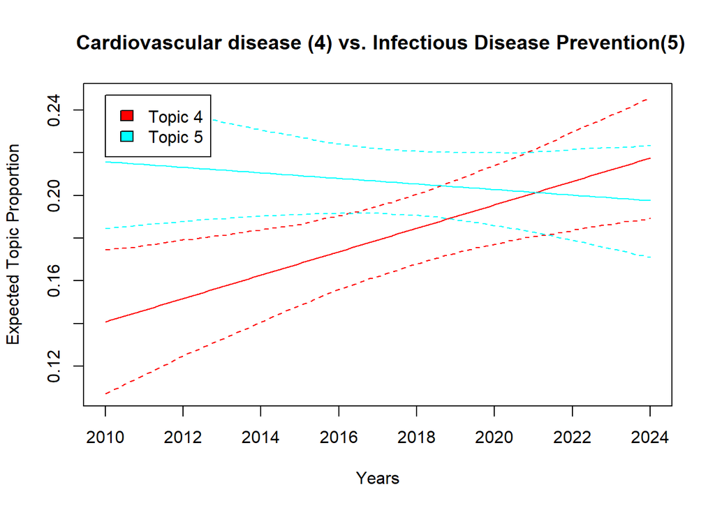

```r
plot(prep, covariate = "year", method = "continuous", topics = c(4, 5), model = stm_fit_disease, xlab = "Years", main = " Cardiovascular disease (4) vs. Infectious Disease Prevention(5)")
```

#### Word Clouds

**Topic 3**

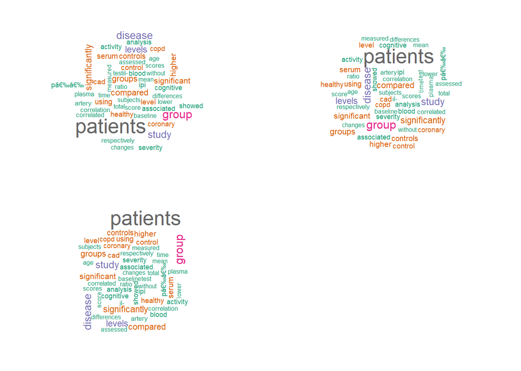

```r
par(mfrow = c(2, 2), mar = c(.1,.1,.1,.1))
for (topic in 1:3) {
  cloud(stm_fit_disease, topic = 3, scale = c(2, 0.5), max.words = 50, colors = brewer.pal(8, "Dark2"))
}
```

**Topic 5**

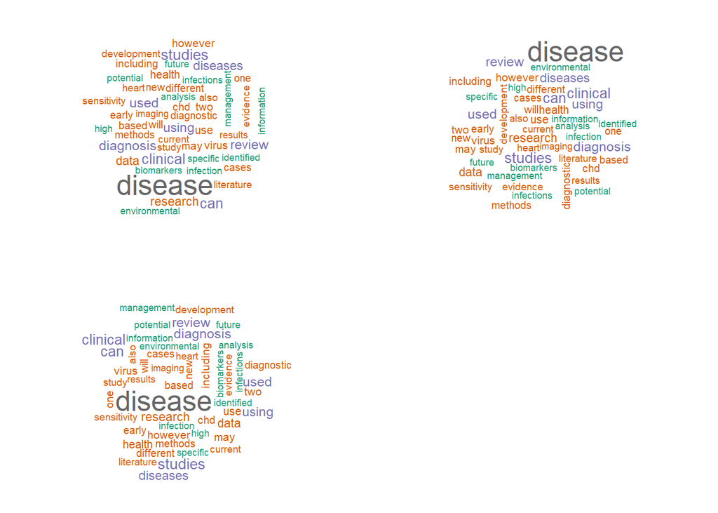

```r
par(mfrow = c(2, 2), mar = c(.1,.1,.1,.1))
for (topic in 1:3) {
  cloud(stm_fit_disease, topic = 5, scale = c(2, 0.5), max.words = 50, colors = brewer.pal(8, "Dark2"))
}
```